# Total Sales R Code

Jorge Fernandez

2024-05-26

**Loading Libraries**

```r
library(ggplot2)
library(ggfortify)
library(janitor)
library(dplyr)
library(lubridate)
library(grid)
library(gridExtra)
library(ggplotify)
library(cowplot)
library(kableExtra)
library(ggpubr)
library(forecast)
library(fBasics)
library(fpp2)
library(zoo)
library(lmtest)
library(tseries)
library(fUnitRoots)
library(astsa)
library(dynlm)
library(FinTS)
library(rugarch)
source("eacf.R")
source("Backtest.R")
source("run_stationarity_tests.R")
source("summarize_arima_models.R")
```

## Read In Data

```r
retail <- read.csv("train.csv")
```

## Some Initial Cleaning

```r
# Clean column names
retail<-clean_names(retail)
colnames(retail)
```

```
##  [1] "row_id"        "order_id"      "order_date"    "ship_date"
##  [5] "ship_mode"     "customer_id"   "customer_name" "segment"
##  [9] "country"       "city"          "state"         "postal_code"
## [13] "region"        "product_id"    "category"      "sub_category"
## [17] "product_name"  "sales"
```

```r
# Convert date cols to Date format
retail$order_date<-as.Date(retail$order_date,'%d/%m/%Y')
retail$ship_date<-as.Date(retail$ship_date, '%d/%m/%Y')
```

## EDA

**Total Orders and Sales by Category**

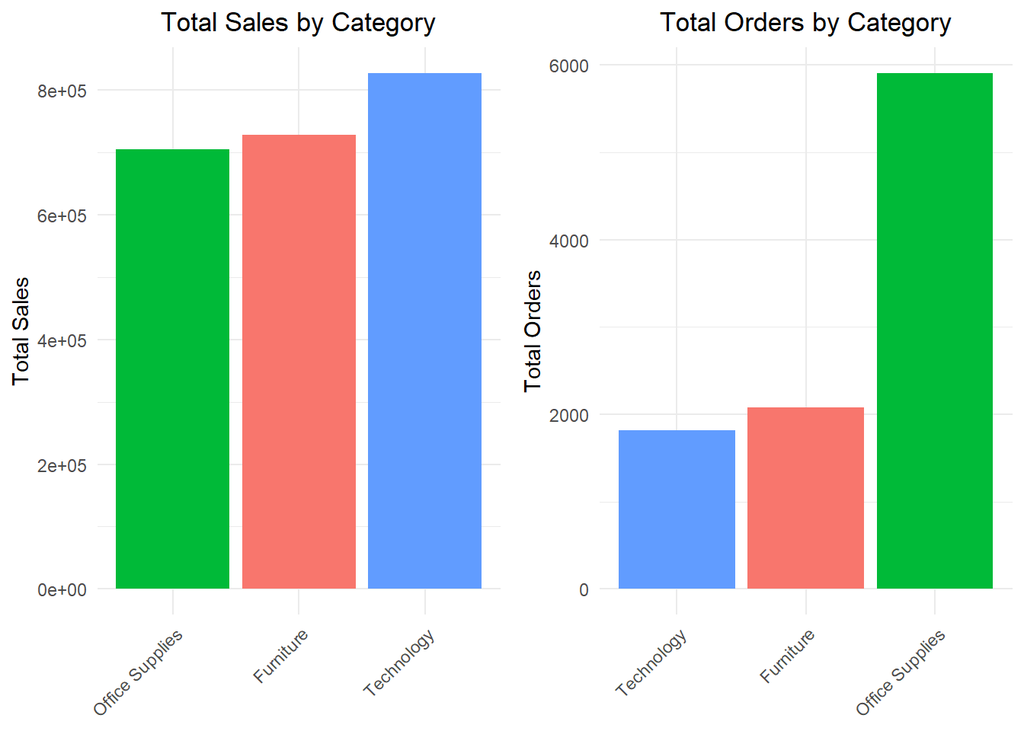

```r
# Summarize total sales by category
sales_by_category <- retail %>%
  group_by(category) %>%
  summarize(total_sales = sum(sales), .groups = 'drop')

# Summarize total orders by category
orders_by_category <- retail %>%
  group_by(category) %>%
  summarize(total_orders = n(), .groups = 'drop')

# Total Sales by Category
sales_plot <- ggplot(sales_by_category, aes(x = reorder(category, total_sales), y = total_sales, fill = category)) +
  geom_col(show.legend = FALSE) +
  labs(title = "Total Sales by Category", x = NULL, y = "Total Sales") +
  theme_minimal() +
  theme(axis.text.x = element_text(angle = 45, hjust = 1),
        plot.title = element_text(hjust = 0.5),
        axis.title.x = element_blank())  # Remove x-axis title

# Total Orders by Category
orders_plot <- ggplot(orders_by_category, aes(x = reorder(category, total_orders), y = total_orders, fill = category)) +
  geom_col(show.legend = FALSE) +
  labs(title = "Total Orders by Category", x = NULL, y = "Total Orders") +
  theme_minimal() +
  theme(axis.text.x = element_text(angle = 45, hjust = 1),
        plot.title = element_text(hjust = 0.5),
        axis.title.x = element_blank())  # Remove x-axis title

# Arrange the plots in a grid
grid.arrange(sales_plot, orders_plot, ncol = 2)
```

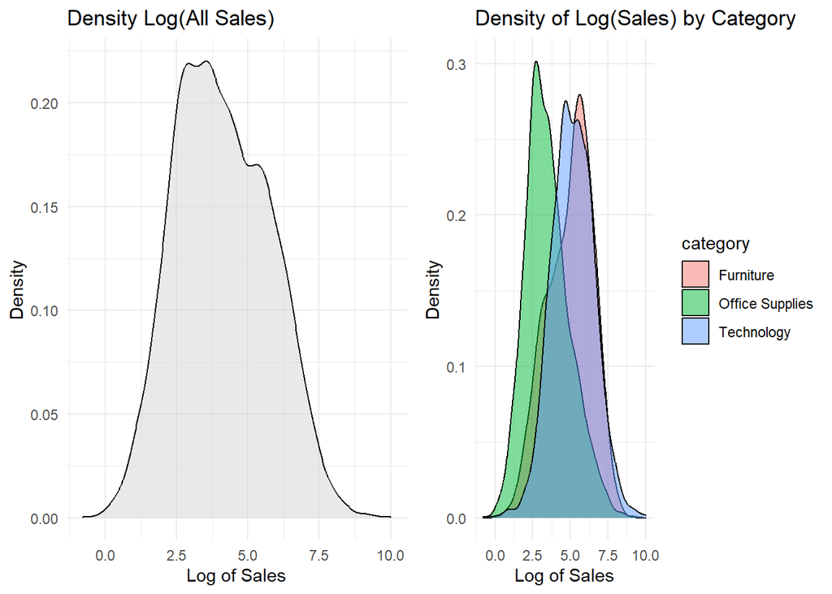

```r
# Add a log of sales column
retail <- retail %>%
  mutate(log_sales = log(sales))

# Plot for the log of all sales
log_sales_plot <- ggplot(retail, aes(x = log_sales)) +
  geom_density(fill = "lightgray", alpha = 0.5) +
  labs(title = "Density Log(All Sales)", x = "Log of Sales", y = "Density") +
  theme_minimal()

# Plot for the log of sales by category
log_sales_by_category_plot <- ggplot(retail, aes(x = log_sales, fill = category)) +
  geom_density(alpha = 0.5) +
  labs(title = "Density of Log(Sales) by Category", x = "Log of Sales", y = "Density") +
  theme_minimal() +
  theme(legend.position = "right")

# Arrange the plots in a grid
grid.arrange(log_sales_plot, log_sales_by_category_plot, ncol = 2)
```

```r
# Ensure order_date is a Date object
retail$order_date <- as.Date(retail$order_date)

# Aggregate total weekly sales
weekly_sales_total <- retail %>%
  mutate(week_year = as.Date(cut(order_date, "week"))) %>%
  group_by(week_year) %>%
  summarize(total_sales = sum(sales), .groups = 'drop')

# Aggregate weekly sales by category
weekly_sales_category <- retail %>%
  mutate(week_year = as.Date(cut(order_date, "week"))) %>%
  group_by(week_year, category) %>%
  summarize(total_sales = sum(sales), .groups = 'drop')

# Plot for total weekly sales
total_sales_plot <- ggplot(weekly_sales_total, aes(x = week_year, y = total_sales)) +
  geom_line(color = "black", size = 0.5, alpha = 0.8) +
  labs(title = "Total Weekly Sales", x = "Week", y = "Sales") +
  theme_minimal() +
  theme(plot.title = element_text(hjust = 0.5))

# Plot for weekly sales by category
sales_by_category_plot <- ggplot(weekly_sales_category, aes(x = week_year, y = total_sales, color = category)) +
  geom_line(size = 0.5, alpha = 0.8) +
  labs(title = "Weekly Sales by Category", x = "Week", y = "Sales") +
  theme_minimal() +
  theme(legend.position = "bottom", plot.title = element_text(hjust = 0.5)) +
  scale_color_manual(values = c("Furniture" = "firebrick", "Office Supplies" = "seagreen", "Technology" = "steelblue"))
```

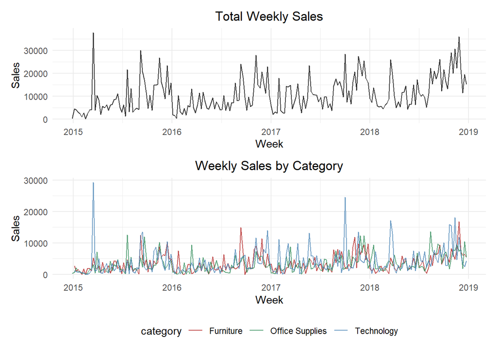

```r
library(patchwork)

# Combining the plots
plot_layout <- (total_sales_plot / sales_by_category_plot) +
  plot_layout(heights = c(15, 16))  # Adjusting relative heights

plot_layout
```

**Total Sales by Day of Week and Month of Year**

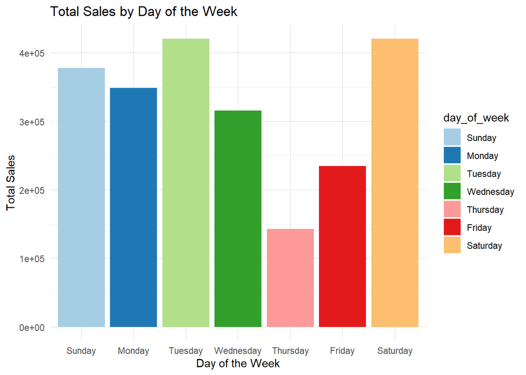

```r
# Adding day of the week column
retail <- retail %>%
  mutate(day_of_week = wday(order_date, label = TRUE, abbr = FALSE))

# Adding month column
retail <- retail %>%
  mutate(month = month(order_date, label = TRUE, abbr = TRUE))

# Summarizing to get total sales by day, month, week
total_sales_by_day <- retail %>%
  group_by(day_of_week) %>%
  summarize(total_sales = sum(sales), .groups = 'drop') %>%
  arrange(day_of_week)

total_sales_by_month <- retail %>%
  group_by(month) %>%
  summarize(total_sales = sum(sales), .groups = 'drop') %>%
  arrange(match(month, month.name))

# Bar plots
ggplot(total_sales_by_day, aes(x = day_of_week, y = total_sales, fill = day_of_week)) +
  geom_bar(stat = "identity") +
  labs(title = "Total Sales by Day of the Week",
       x = "Day of the Week",
       y = "Total Sales") +
  theme_minimal() +
  scale_fill_brewer(palette = "Paired")
```

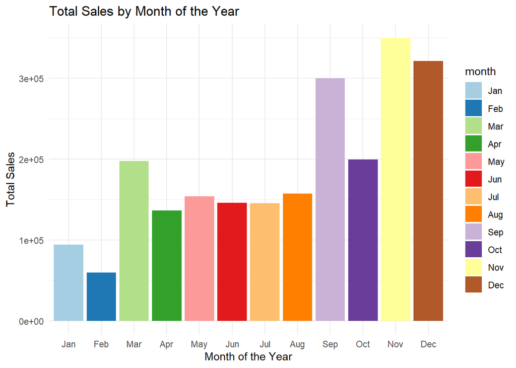

```r
ggplot(total_sales_by_month, aes(x = month, y = total_sales, fill = month)) +
  geom_bar(stat = "identity") +
  labs(title = "Total Sales by Month of the Year",
       x = "Month of the Year",
       y = "Total Sales") +
  theme_minimal() +
  scale_fill_brewer(palette = "Paired")
```

**Total Sales by Day of the Month**

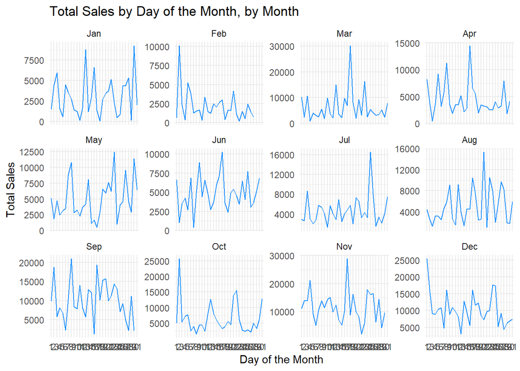

```r
# Extract day of the month and month name
retail <- retail %>%
  mutate(day_of_month = day(order_date),
         month_name = month(order_date, label = TRUE, abbr = TRUE))  # abbr = TRUE for abbreviated month names

# Summarize
sales_by_day_month <- retail %>%
  group_by(month_name, day_of_month) %>%
  summarize(total_sales = sum(sales), .groups = 'drop') %>%
  arrange(month_name, day_of_month)

# Line plot with faceting for each month
ggplot(sales_by_day_month, aes(x = as.factor(day_of_month), y = total_sales, group = 1)) +
  geom_line(color = "dodgerblue") +
  facet_wrap(~month_name, scales = "free_y") +
  labs(title = "Total Sales by Day of the Month, by Month",
       x = "Day of the Month",
       y = "Total Sales") +
  theme_minimal()
```

## Weekly Aggregation

```r
# Group by year and week, and summarize sales
weekly_sales <- retail %>%
  mutate(week_year = as.Date(cut(order_date, "week"))) %>%
  group_by(week_year) %>%
  summarize(total_sales = sum(sales), .groups = 'drop')

# Create a zoo object
sales_zoo_weekly <- zoo(weekly_sales$total_sales, order.by = weekly_sales$week_year)
sales_ts_weekly <- ts(weekly_sales$total_sales, frequency=52)
```

**Plotting time series data vs time w/ Loess Regression line**

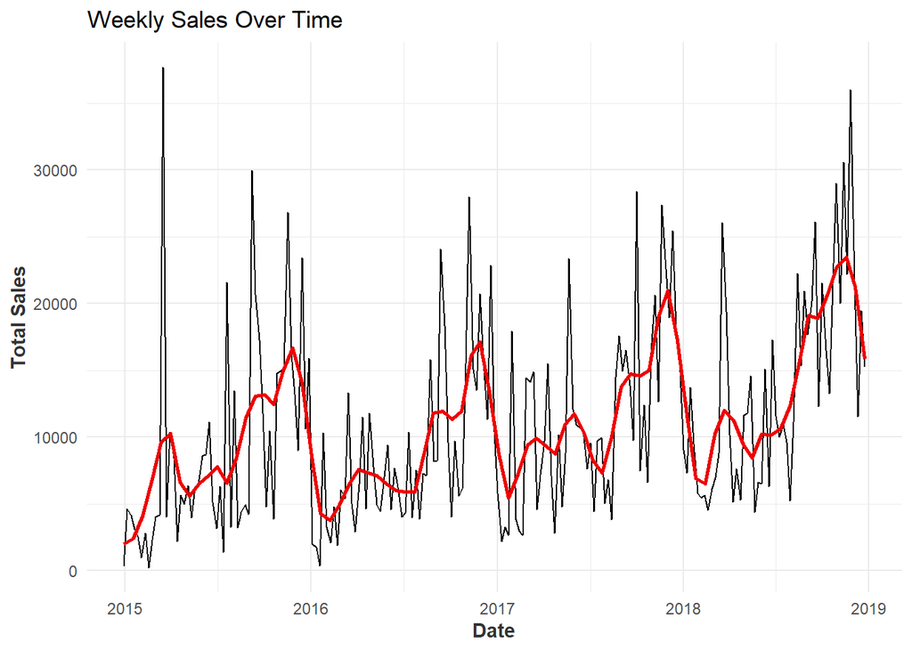

```r
# Convert zoo object to a data frame for ggplot
sales_data_frame <- data.frame(Date = index(sales_zoo_weekly), Sales = coredata(sales_zoo_weekly))

# Create an enhanced time series plot using ggplot2
ggplot(sales_data_frame, aes(x = Date, y = Sales)) +
  geom_line(color = "black") +  # Customize line color and thickness
  geom_smooth(method = "loess", color = "red2", se = FALSE, span = 0.1) +
  labs(title = "Weekly Sales Over Time", x = "Date", y = "Total Sales") +
  theme_minimal() +  # Use a minimalistic theme
  theme(axis.title.x = element_text(face = "bold", color = "gray20"),  # Customize x-axis title
        axis.title.y = element_text(face = "bold", color = "gray20"))  # Customize y-axis title
```

- Perhaps some multiplicative behavior, though maybe not
- Definite seasonality

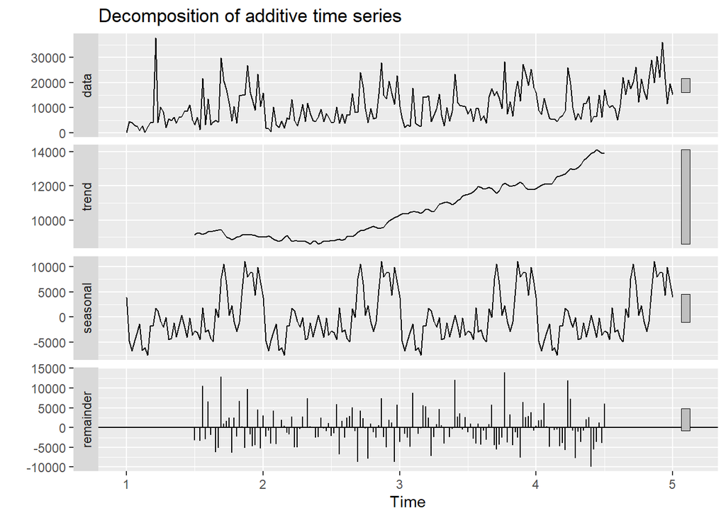

```r
autoplot(decompose(sales_ts_weekly))
```

**Checking for Normality**

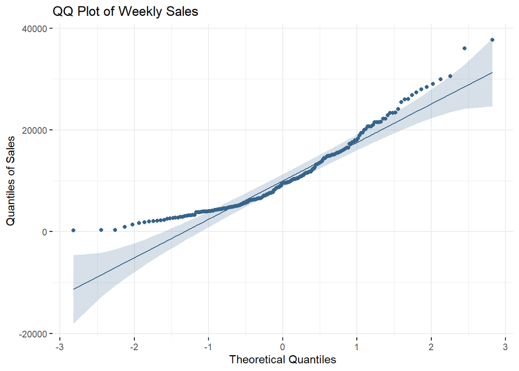

```r
ggqqplot(sales_ts_weekly,
                    ylab = "Quantiles of Sales",
                    xlab = "Theoretical Quantiles",
                    ggtheme = theme_minimal(),
                    color = "steelblue4",
                    conf.int = TRUE,
                    title = "QQ Plot of Weekly Sales")
```

```r
jb_test <- jarque.bera.test(sales_ts_weekly)
print(jb_test) # small p-value so data comes from non-normal distribution
```

```
##
##  Jarque Bera Test
##
## data:  sales_ts_weekly
## X-squared = 41.866, df = 2, p-value = 8.107e-10
```

**ACF and PACF plots**

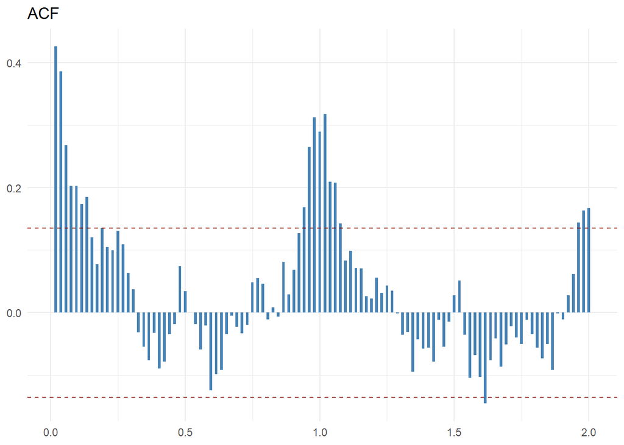

```r
# significance level
N <- length(sales_ts_weekly)
sig_level <- 1.96 / sqrt(N)

# Exract acf and pacf data
acf_data <- acf(sales_ts_weekly, lag.max = 104, plot = FALSE)
pacf_data <- pacf(sales_ts_weekly, lag.max = 104, plot = FALSE)

# ACF Plot with significance lines
ggplot(data.frame(Lag = acf_data$lag[-1], ACF = acf_data$acf[-1]), aes(x = Lag, y = ACF)) +  # Exclude lag 0
  geom_bar(stat = "identity", fill = "steelblue", width = 0.01) +
  geom_hline(yintercept = c(-sig_level, sig_level), linetype = "dashed", color = "darkred") +
  labs(title = "ACF", x = "Lag", y = "ACF") +
  theme_minimal() +
  theme(axis.title.x = element_blank(),
        axis.title.y = element_blank())
```

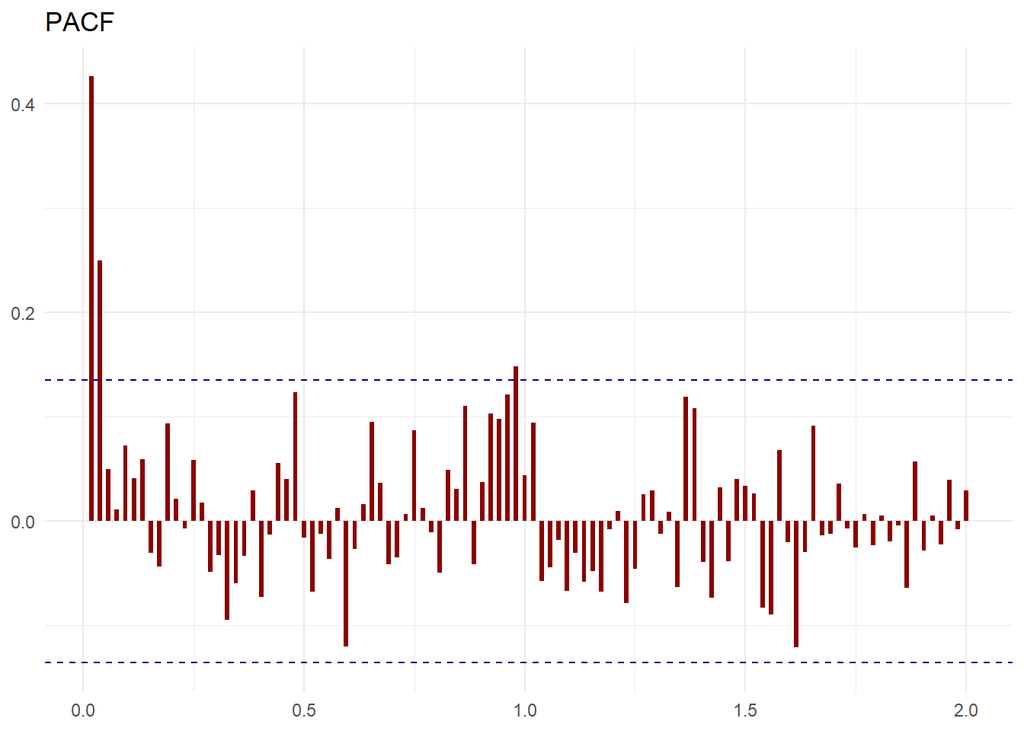

```r
# PACF Plot with significance lines
ggplot(data.frame(Lag = pacf_data$lag, PACF = pacf_data$acf), aes(x = Lag, y = PACF)) +
  geom_bar(stat = "identity", fill = "darkred", width = 0.01) +
  geom_hline(yintercept = c(-sig_level, sig_level), linetype = "dashed", color = "darkblue") +
  labs(title = "PACF", x = "Lag", y = "PACf") +
  theme_minimal() +
  theme(axis.title.x = element_blank(),
        axis.title.y = element_blank())
```

$\text{\underline{Stationarity}}$

- Most tests indicate that the series is stationary, however the KPSS test indicates the series is *not* level stationary.
- 1st Differences t-test: Suggests that the series does not have a strong deterministic trend. Since the mean of the first differences is not significantly different from zero, it implies that any trend in the original series is likely stochastic rather than deterministic.

$\text{\underline{Seasonality}}$

- The ACF plot definitely indicates seasonality, at about 52 lags (52 weeks = 1 year)

$\text{\underline{ARMA Order}}$ - ACF suggests higher order MA (7 significant lags) - PACF suggests maybe AR(2)

**Looking at mean of differences**

```r
mean(diff(sales_ts_weekly))
```

```
## [1] 71.66528
```

```r
t.test(diff(sales_ts_weekly)) # cannot reject that the mean is actually 0
```

```
##
##  One Sample t-test
##
## data:  diff(sales_ts_weekly)
## t = 0.13065, df = 207, p-value = 0.8962
## alternative hypothesis: true mean is not equal to 0
## 95 percent confidence interval:
##  -1009.747  1153.078
## sample estimates:
## mean of x
##  71.66528
```

**KPSS and ADF Tests**

```r
# summary_table = summarize_arima_models(model1,model2, model3, model4, model5, model6)
# kable(table, format = "html", caption = "Manual Models") %>%
#   kable_classic(full_width = F, html_font = "Cambria")

run_stationarity_tests(sales_ts_weekly)
```

```
##                Test   Statistic P_Value   Stationarity
## 1   ADF (zero-mean) -2.61814445    0.01     Stationary
## 2 ADF (single-mean) -5.92572008    0.01     Stationary
## 3  ADF (time-trend) -6.72556386    0.01     Stationary
## 4      KPSS (level)  1.22086277    0.01 Non-Stationary
## 5      KPSS (trend)  0.09635634    0.10     Stationary
```

**Since there seems to be a stochastic trend, maybe differencing is appropriate**

## Looking at 2-Stage Differenced Timeseries

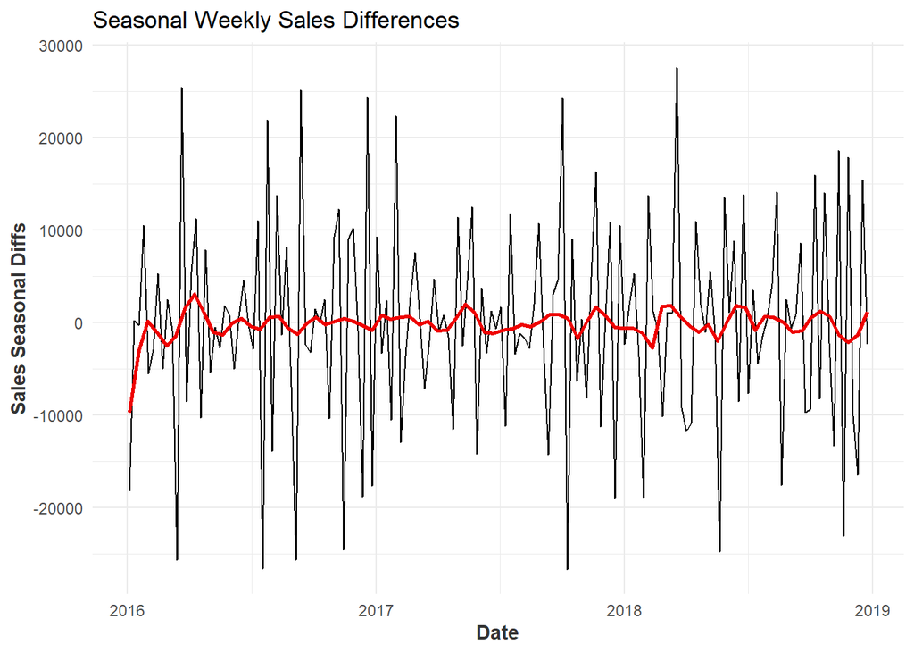

```r
two_diff_zoo = diff(diff(sales_zoo_weekly), 52)
two_diff_ts = diff(diff(sales_ts_weekly), 52)

# Convert zoo object to a data frame for ggplot
diff_data_frame <- data.frame(Date = index(two_diff_zoo), Sales = coredata(two_diff_zoo))

# Time series plot using ggplot2
ggplot(diff_data_frame, aes(x = Date, y = Sales)) +
  geom_line(color = "black") +
  geom_smooth(method = "loess", color = "red2", se = FALSE, span = 0.1) +
  labs(title = "Seasonal Weekly Sales Differences", x = "Date", y = "Sales Seasonal Diffs") +
  theme_minimal() +
  theme(axis.title.x = element_text(face = "bold", color = "gray20"),
        axis.title.y = element_text(face = "bold", color = "gray20"))
```

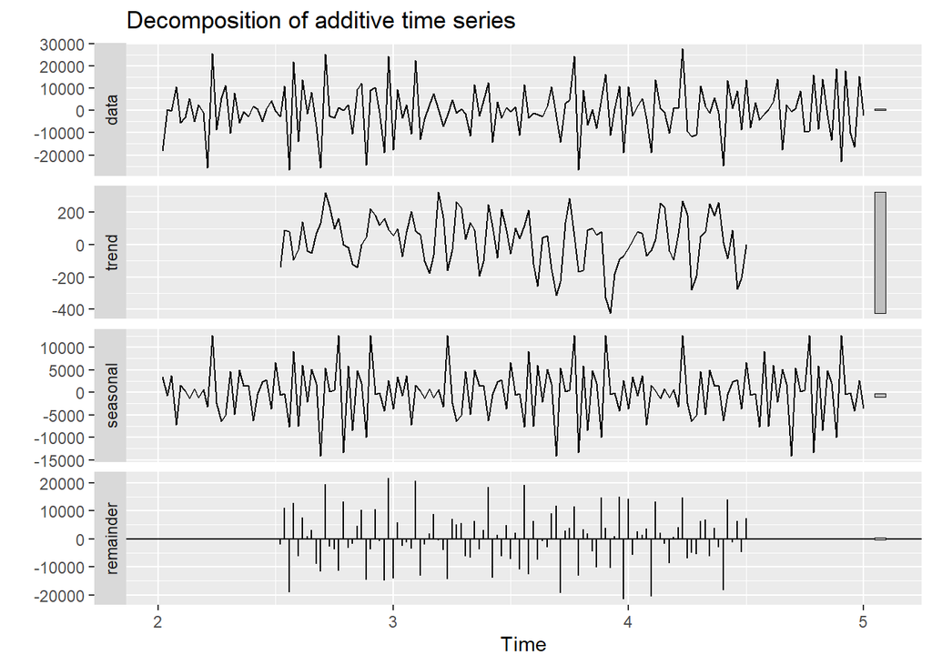

```r
autoplot(decompose(two_diff_ts))
```

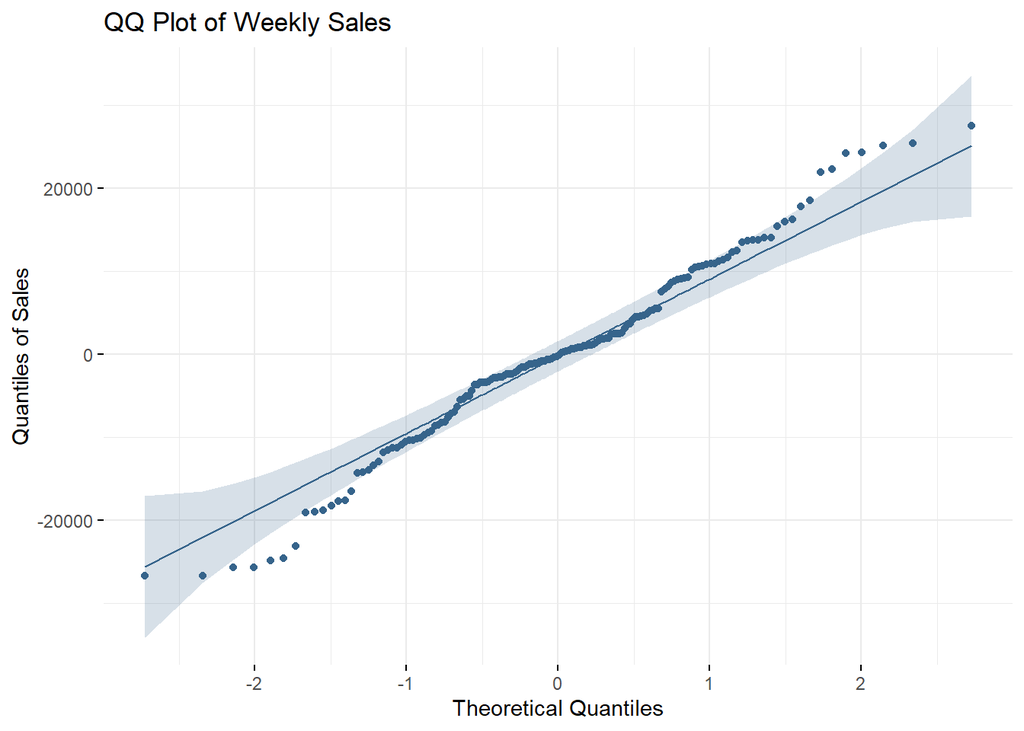

```r
ggqqplot(two_diff_ts,
                    ylab = "Quantiles of Sales",
                    xlab = "Theoretical Quantiles",
                    ggtheme = theme_minimal(),
                    color = "steelblue4",
                    conf.int = TRUE,
                    title = "QQ Plot of Weekly Sales")
```

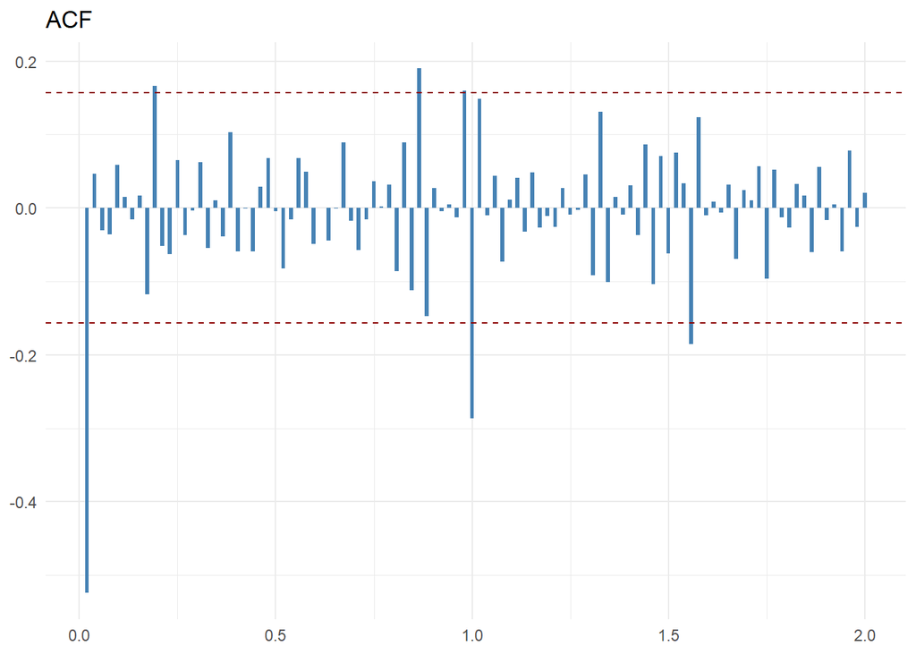

```r
# significance level
N <- length(two_diff_ts)
sig_level <- 1.96 / sqrt(N)

# Exract acf and pacf data
acf_data <- acf(two_diff_ts, lag.max = 104, plot = FALSE)
pacf_data <- pacf(two_diff_ts, lag.max = 104, plot = FALSE)

# ACF Plot with significance lines
ggplot(data.frame(Lag = acf_data$lag[-1], ACF = acf_data$acf[-1]), aes(x = Lag, y = ACF)) +  # Exclude lag 0
  geom_bar(stat = "identity", fill = "steelblue", width = 0.01) +
  geom_hline(yintercept = c(-sig_level, sig_level), linetype = "dashed", color = "darkred") +
  labs(title = "ACF", x = "Lag", y = "ACF") +
  theme_minimal() +
  theme(axis.title.x = element_blank(),
        axis.title.y = element_blank())
```

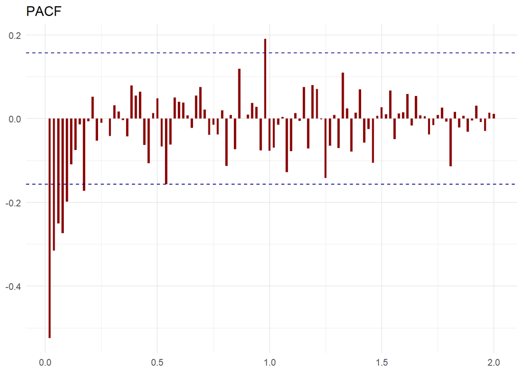

```r
# PACF Plot with significance lines
ggplot(data.frame(Lag = pacf_data$lag, PACF = pacf_data$acf), aes(x = Lag, y = PACF)) +
  geom_bar(stat = "identity", fill = "darkred", width = 0.01) +
  geom_hline(yintercept = c(-sig_level, sig_level), linetype = "dashed", color = "darkblue") +
  labs(title = "PACF", x = "Lag", y = "PACf") +
  theme_minimal() +
  theme(axis.title.x = element_blank(),
        axis.title.y = element_blank())
```

```r
run_stationarity_tests(two_diff_ts)
```

```
##                Test    Statistic P_Value Stationarity
## 1   ADF (zero-mean) -15.23269607    0.01   Stationary
## 2 ADF (single-mean) -15.18155173    0.01   Stationary
## 3  ADF (time-trend) -15.13307933    0.01   Stationary
## 4      KPSS (level)   0.03603613    0.10   Stationary
## 5      KPSS (trend)   0.02854188    0.10   Stationary
```

```r
# Jarque-Bera test
jb_test <- jarque.bera.test(two_diff_ts)
print(jb_test) # Large p-value so data comes from normal distribution
```

```
##
##  Jarque Bera Test
##
## data:  two_diff_ts
## X-squared = 0.3002, df = 2, p-value = 0.8606
```

```r
run_stationarity_tests(two_diff_ts)
```

```
##                Test    Statistic P_Value Stationarity
## 1   ADF (zero-mean) -15.23269607    0.01   Stationary
## 2 ADF (single-mean) -15.18155173    0.01   Stationary
## 3  ADF (time-trend) -15.13307933    0.01   Stationary
## 4      KPSS (level)   0.03603613    0.10   Stationary
## 5      KPSS (trend)   0.02854188    0.10   Stationary
```

$\text{\underline{Stationarity}}$

## Making SARIMA Models

Building Model Based off Previous Analysis:

```r
model1 = Arima(sales_ts_weekly, order=c(0, 1, 1), seasonal=list(order=c(0, 1, 1), period=52))
summary(model1)
```

```
## Series: sales_ts_weekly
## ARIMA(0,1,1)(0,1,1)[52]
##
## Coefficients:
##           ma1     sma1
##       -0.9732  -0.6423
## s.e.   0.0238   0.1891
##
## sigma^2 = 41805213:  log likelihood = -1603.8
## AIC=3213.6   AICc=3213.76   BIC=3222.75
##
## Training set error measures:
##                    ME     RMSE      MAE       MPE     MAPE      MASE       ACF1
## Training set 268.5683 5550.121 3474.174 -21.59893 45.63601 0.6201186 -0.0838657
```

```r
coeftest(model1)
```

```
##
## z test of coefficients:
##
##       Estimate Std. Error  z value  Pr(>|z|)
## ma1  -0.973232   0.023787 -40.9138 < 2.2e-16 ***
## sma1 -0.642345   0.189099  -3.3969 0.0006816 ***
## ---
## Signif. codes:  0 '***' 0.001 '**' 0.01 '*' 0.05 '.' 0.1 ' ' 1
```

```r
Acf(model1$residuals, lag.max=52)
pacf(model1$residuals, lag.max=52)
Box.test(model1$residuals, type="L")
```

```
##
##  Box-Ljung test
##
## data:  model1$residuals
## X-squared = 1.4912, df = 1, p-value = 0.222
```

```r
plot(forecast(model1, h=52))
```

Auto Arima Models:

```r
auto_with_aic = auto.arima(sales_ts_weekly, ic='aic')
summary(auto_with_aic)
```

```
## Series: sales_ts_weekly
## ARIMA(5,1,0)(1,0,0)[52] with drift
##
## Coefficients:
##           ar1      ar2      ar3      ar4      ar5    sar1     drift
##       -0.6770  -0.3959  -0.3264  -0.2978  -0.1397  0.1521   77.6872
## s.e.   0.0743   0.0876   0.0868   0.0833   0.0697  0.0932  181.7012
##
## sigma^2 = 44183762:  log likelihood = -2123.34
## AIC=4262.68   AICc=4263.4   BIC=4289.38
##
## Training set error measures:
##                    ME     RMSE      MAE       MPE     MAPE      MASE
## Training set 8.854904 6518.629 4700.936 -50.61879 77.61622 0.8390879
##                     ACF1
## Training set -0.02134998
```

```r
coeftest(auto_with_aic)
```

```
##
## z test of coefficients:
##
##         Estimate Std. Error z value  Pr(>|z|)
## ar1    -0.676987   0.074295 -9.1121 < 2.2e-16 ***
## ar2    -0.395929   0.087615 -4.5190 6.214e-06 ***
## ar3    -0.326425   0.086779 -3.7616 0.0001688 ***
## ar4    -0.297775   0.083291 -3.5751 0.0003501 ***
## ar5    -0.139725   0.069727 -2.0039 0.0450817 *
## sar1    0.152062   0.093200  1.6316 0.1027708
## drift  77.687236 181.701159  0.4276 0.6689751
## ---
## Signif. codes:  0 '***' 0.001 '**' 0.01 '*' 0.05 '.' 0.1 ' ' 1
```

```r
Acf(auto_with_aic$residuals, lag.max=52)
pacf(auto_with_aic$residuals, lag.max=52)
Box.test(auto_with_aic$residuals, type="L")
```

```
##
##  Box-Ljung test
##
## data:  auto_with_aic$residuals
## X-squared = 0.096641, df = 1, p-value = 0.7559
```

```r
plot(forecast(auto_with_aic, h=52))
```

```r
auto_with_bic = auto.arima(sales_ts_weekly, ic='bic')
print(auto_with_bic)
```

```
## Series: sales_ts_weekly
## ARIMA(0,1,1)(1,0,0)[52]
##
## Coefficients:
##           ma1    sar1
##       -0.8227  0.2330
## s.e.   0.0580  0.0932
##
## sigma^2 = 41789242:  log likelihood = -2121.16
## AIC=4248.32   AICc=4248.43   BIC=4258.33
```

```r
coeftest(auto_with_bic)
```

```
##
## z test of coefficients:
##
##       Estimate Std. Error  z value Pr(>|z|)
## ma1  -0.822696   0.058037 -14.1755  < 2e-16 ***
## sar1  0.232970   0.093249   2.4984  0.01248 *
## ---
## Signif. codes:  0 '***' 0.001 '**' 0.01 '*' 0.05 '.' 0.1 ' ' 1
```

```r
Acf(auto_with_bic$residuals, lag.max=52)
pacf(auto_with_bic$residuals, lag.max=52)
Box.test(auto_with_bic$residuals, type="L")
```

```
##
##  Box-Ljung test
##
## data:  auto_with_bic$residuals
## X-squared = 0.80375, df = 1, p-value = 0.37
```

```r
plot(forecast(auto_with_bic, h=52))
```

**auto.arima with Box Cox**

```r
auto_with_aic = auto.arima(sales_ts_weekly, ic='aic', lambda="auto")
print(auto_with_aic)
```

```
## Series: sales_ts_weekly
## ARIMA(5,1,0)(1,0,0)[52] with drift
## Box Cox transformation: lambda= 0.838912
##
## Coefficients:
##           ar1      ar2      ar3      ar4      ar5    sar1    drift
##       -0.6707  -0.3792  -0.3280  -0.3028  -0.1375  0.1505  18.0051
## s.e.   0.0745   0.0873   0.0859   0.0827   0.0696  0.0919  39.6471
##
## sigma^2 = 2081569:  log likelihood = -1805.58
## AIC=3627.16   AICc=3627.89   BIC=3653.86
```

```r
coeftest(auto_with_aic)
```

```
##
## z test of coefficients:
##
##        Estimate Std. Error z value  Pr(>|z|)
## ar1   -0.670650   0.074481 -9.0043 < 2.2e-16 ***
## ar2   -0.379218   0.087318 -4.3430 1.406e-05 ***
## ar3   -0.328031   0.085927 -3.8176 0.0001348 ***
## ar4   -0.302795   0.082687 -3.6620 0.0002503 ***
## ar5   -0.137533   0.069561 -1.9771 0.0480251 *
## sar1   0.150534   0.091923  1.6376 0.1015037
## drift 18.005064  39.647055  0.4541 0.6497326
## ---
## Signif. codes:  0 '***' 0.001 '**' 0.01 '*' 0.05 '.' 0.1 ' ' 1
```

```r
Acf(auto_with_aic$residuals, lag.max=52)
pacf(auto_with_aic$residuals, lag.max=52)
Box.test(auto_with_aic$residuals, type="L")
```

```
##
##  Box-Ljung test
##
## data:  auto_with_aic$residuals
## X-squared = 0.080733, df = 1, p-value = 0.7763
```

```r
plot(forecast(auto_with_aic, h=52))
```

```r
auto_with_bic = auto.arima(sales_ts_weekly, ic='bic', lambda='auto')
print(auto_with_bic)
```

```
## Series: sales_ts_weekly
## ARIMA(0,1,1)(1,0,0)[52]
## Box Cox transformation: lambda= 0.838912
##
## Coefficients:
##           ma1    sar1
##       -0.8163  0.2331
## s.e.   0.0601  0.0927
##
## sigma^2 = 1982879:  log likelihood = -1804.14
## AIC=3614.28   AICc=3614.4   BIC=3624.3
```

```r
coeftest(auto_with_bic)
```

```
##
## z test of coefficients:
##
##       Estimate Std. Error  z value Pr(>|z|)
## ma1  -0.816308   0.060091 -13.5846  < 2e-16 ***
## sar1  0.233103   0.092705   2.5144  0.01192 *
## ---
## Signif. codes:  0 '***' 0.001 '**' 0.01 '*' 0.05 '.' 0.1 ' ' 1
```

```r
Acf(auto_with_bic$residuals, lag.max=52)
pacf(auto_with_bic$residuals, lag.max=52)
Box.test(auto_with_bic$residuals, type="L")
```

```
##
##  Box-Ljung test
##
## data:  auto_with_bic$residuals
## X-squared = 0.87351, df = 1, p-value = 0.35
```

```r
plot(forecast(auto_with_bic, h=52))
```

**Generating models with different parameter combinations**

```r
# Non-seasonal ARIMA orders
orders <- expand.grid(p = 0:2, d = 1, q = 0:2)

# Seasonal ARIMA orders
seasonal_orders <- expand.grid(P = 0:1, D = 0:1, Q = 0:1, s = 52)

# Initialize lists
model_list <- list()
problematic_models <- list()
```

```r
# Generate models with all combinations
for (i in 1:nrow(orders)) {
  for (j in 1:nrow(seasonal_orders)) {
    model_label <- paste("model",
                         paste(orders[i, ], collapse = "_"),
                         "x",
                         paste(seasonal_orders[j, ], collapse = "_"),
                         sep = "_")
    # tryCatch to handle errors
    result <- tryCatch({
      # Fit ARIMA model
      Arima(sales_ts_weekly,
            order = as.numeric(orders[i, 1:3]),
            seasonal = list(order = as.numeric(seasonal_orders[j, 1:3]),
                            period = as.integer(seasonal_orders[j, 4]))
      ) # Correctly close Arima function call
    },
    error = function(e) {
        # Handle error by returning NULL and logging the error
        cat(sprintf("Error in model %s: %s\n", model_label, e$message))
        return(NULL)
    })

    # Only store successful models
    if (!is.null(result)) {
      model_list[[model_label]] <- result
    } else {
      # Store problematic model configurations
      problematic_models[[model_label]] <- list(order = orders[i, ], seasonal_order = seasonal_orders[j, ])
    }
  }
}
```

[output not shown]

**Best Models**

```r
model1 = Arima(sales_ts_weekly, order=c(0, 1, 1), seasonal=list(order=c(0, 1, 1), period=52))
summary(model1)
```

```
## Series: sales_ts_weekly
## ARIMA(0,1,1)(0,1,1)[52]
##
## Coefficients:
##           ma1     sma1
##       -0.9732  -0.6423
## s.e.   0.0238   0.1891
##
## sigma^2 = 41805213:  log likelihood = -1603.8
## AIC=3213.6   AICc=3213.76   BIC=3222.75
##
## Training set error measures:
##                    ME     RMSE      MAE       MPE     MAPE      MASE       ACF1
## Training set 268.5683 5550.121 3474.174 -21.59893 45.63601 0.6201186 -0.0838657
```

```r
coeftest(model1)
```

```
##
## z test of coefficients:
##
##       Estimate Std. Error  z value  Pr(>|z|)
## ma1  -0.973232   0.023787 -40.9138 < 2.2e-16 ***
## sma1 -0.642345   0.189099  -3.3969 0.0006816 ***
## ---
## Signif. codes:  0 '***' 0.001 '**' 0.01 '*' 0.05 '.' 0.1 ' ' 1
```

```r
Acf(model1$residuals, lag.max=52)
pacf(model1$residuals, lag.max=52)
Box.test(model1$residuals, type="L")
```

```
##
##  Box-Ljung test
##
## data:  model1$residuals
## X-squared = 1.4912, df = 1, p-value = 0.222
```

```r
plot(forecast(model1, h=52))
```

```r
model2 = Arima(sales_ts_weekly, order=c(0, 1, 2), seasonal=list(order=c(0, 1, 1), period=52))
summary(model2)
```

```
## Series: sales_ts_weekly
## ARIMA(0,1,2)(0,1,1)[52]
##
## Coefficients:
##           ma1     ma2     sma1
##       -1.0895  0.1213  -0.6467
## s.e.   0.0873  0.0875   0.1921
##
## sigma^2 = 41480973:  log likelihood = -1602.82
## AIC=3213.65   AICc=3213.91   BIC=3225.85
##
## Training set error measures:
##                    ME     RMSE      MAE       MPE     MAPE      MASE       ACF1
## Training set 268.2713 5510.577 3509.793 -21.71774 46.50915 0.6264763 0.02522499
```

```r
coeftest(model2)
```

```
##
## z test of coefficients:
##
##       Estimate Std. Error  z value  Pr(>|z|)
## ma1  -1.089493   0.087304 -12.4792 < 2.2e-16 ***
## ma2   0.121326   0.087458   1.3873 0.1653654
## sma1 -0.646740   0.192057  -3.3674 0.0007587 ***
## ---
## Signif. codes:  0 '***' 0.001 '**' 0.01 '*' 0.05 '.' 0.1 ' ' 1
```

```r
Acf(model2$residuals, lag.max=104)
pacf(model2$residuals, lag.max=104)
Box.test(model2$residuals, type="L")
```

```
##
##  Box-Ljung test
##
## data:  model2$residuals
## X-squared = 0.1349, df = 1, p-value = 0.7134
```

```r
plot(forecast(model2, h=104))
```

```r
model3 = Arima(sales_ts_weekly, order=c(1, 1, 2), seasonal=list(order=c(0, 1, 1), period=52))
summary(model3)
```

```
## Series: sales_ts_weekly
## ARIMA(1,1,2)(0,1,1)[52]
##
## Coefficients:
##          ar1      ma1     ma2     sma1
##       0.5664  -1.6706  0.6910  -0.6742
## s.e.  0.2193   0.1891  0.1842   0.2117
##
## sigma^2 = 40564546:  log likelihood = -1601.8
## AIC=3213.6   AICc=3214   BIC=3228.85
##
## Training set error measures:
##                    ME     RMSE      MAE       MPE     MAPE      MASE       ACF1
## Training set 210.8469 5431.527 3499.543 -21.87786 46.75514 0.6246466 0.02899057
```

```r
coeftest(model3)
```

```
##
## z test of coefficients:
##
##      Estimate Std. Error z value  Pr(>|z|)
## ar1   0.56645    0.21930  2.5829 0.0097960 **
## ma1  -1.67061    0.18910 -8.8343 < 2.2e-16 ***
## ma2   0.69102    0.18416  3.7523 0.0001752 ***
## sma1 -0.67425    0.21166 -3.1855 0.0014448 **
## ---
## Signif. codes:  0 '***' 0.001 '**' 0.01 '*' 0.05 '.' 0.1 ' ' 1
```

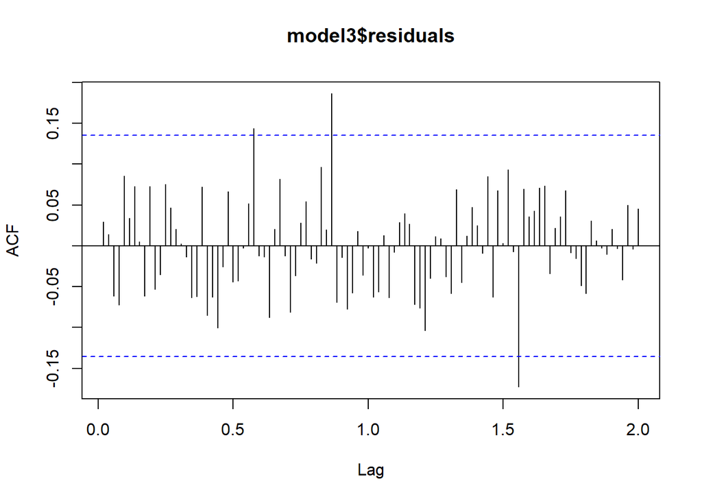

```r
Acf(model3$residuals, lag.max=104)
```

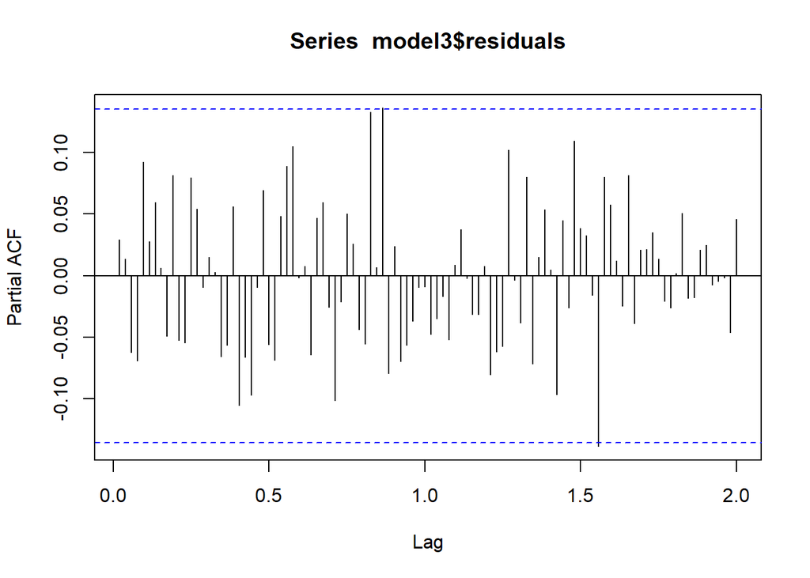

```r
pacf(model3$residuals, lag.max=104)
```

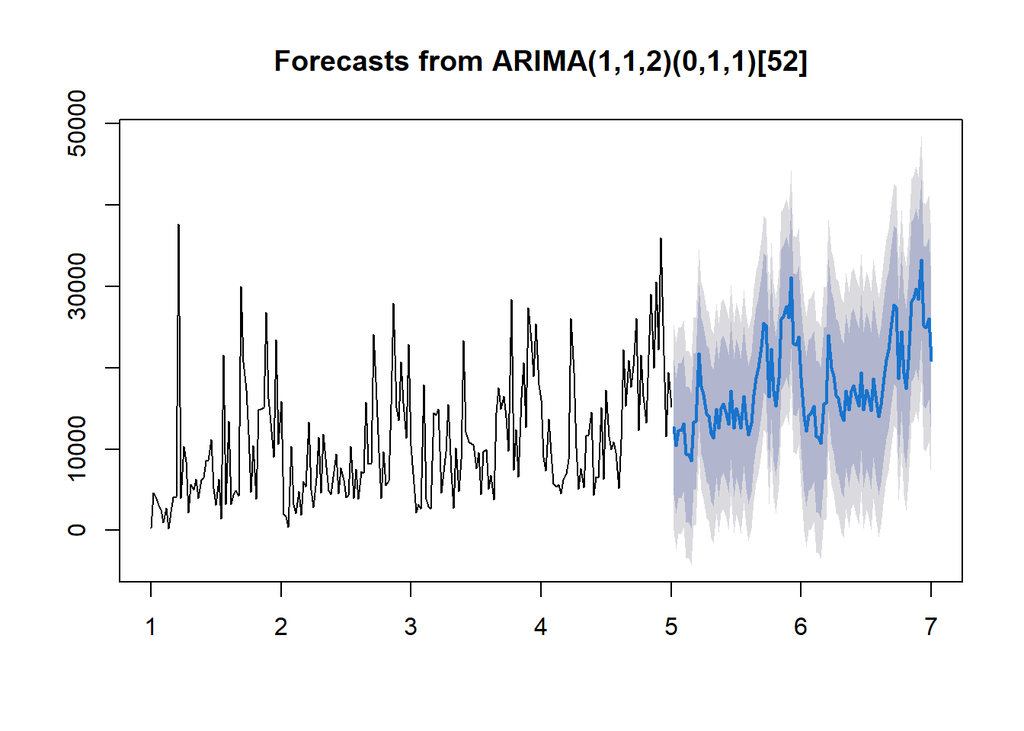

```r
plot(forecast(model3, h=104))
```

```r
model_new = Arima(sales_ts_weekly, order=c(5, 1, 1), seasonal=list(order=c(1, 1, 1), period=52))
summary(model_new)
```

```
## Series: sales_ts_weekly
## ARIMA(5,1,1)(1,1,1)[52]
##
## Coefficients:
##           ar1      ar2      ar3      ar4     ar5      ma1     sar1     sma1
##       -0.1744  -0.1077  -0.1715  -0.1706  0.0118  -0.9209  -0.2125  -0.4649
## s.e.      NaN   0.1326   0.0986   0.0497  0.1454   0.0511      NaN   0.1584
##
## sigma^2 = 41727624:  log likelihood = -1599.68
## AIC=3217.36   AICc=3218.59   BIC=3244.81
##
## Training set error measures:
##                    ME     RMSE      MAE       MPE     MAPE      MASE       ACF1
## Training set 201.4442 5435.876 3580.793 -21.16134 46.74964 0.6391493 0.01782748
```

```r
coeftest(model_new)
```

```
##
## z test of coefficients:
##
##       Estimate Std. Error  z value  Pr(>|z|)
## ar1  -0.174431        NaN      NaN       NaN
## ar2  -0.107737   0.132556  -0.8128 0.4163491
## ar3  -0.171478   0.098566  -1.7397 0.0819056 .
## ar4  -0.170584   0.049732  -3.4301 0.0006035 ***
## ar5   0.011818   0.145430   0.0813 0.9352337
## ma1  -0.920919   0.051091 -18.0251 < 2.2e-16 ***
## sar1 -0.212504        NaN      NaN       NaN
## sma1 -0.464887   0.158353  -2.9358 0.0033273 **
## ---
## Signif. codes:  0 '***' 0.001 '**' 0.01 '*' 0.05 '.' 0.1 ' ' 1
```

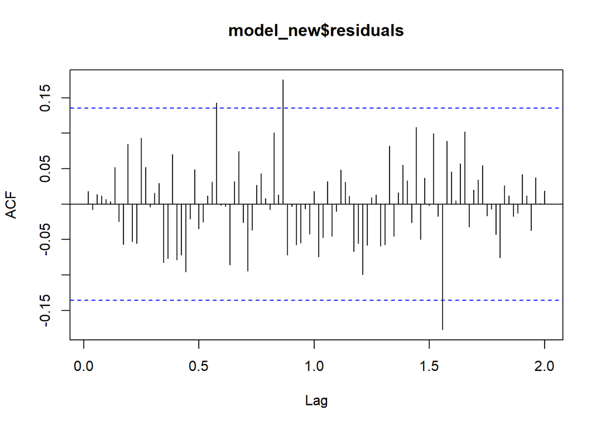

```r
Acf(model_new$residuals, lag.max=104)
```

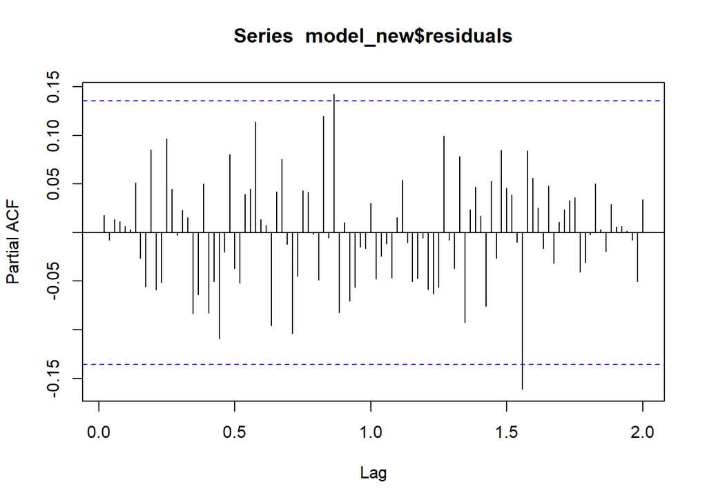

```r
pacf(model_new$residuals, lag.max=104)
```

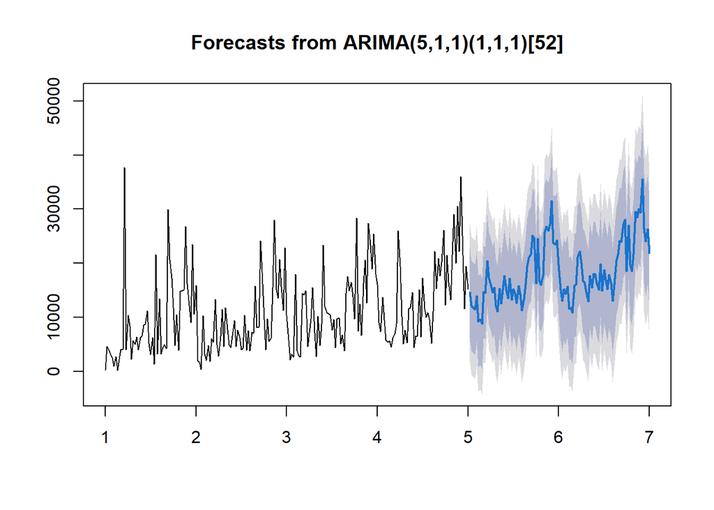

```r
plot(forecast(model_new, h=104))
```

**Including Box-Cox Tranforms**

```r
library("MASS")
```

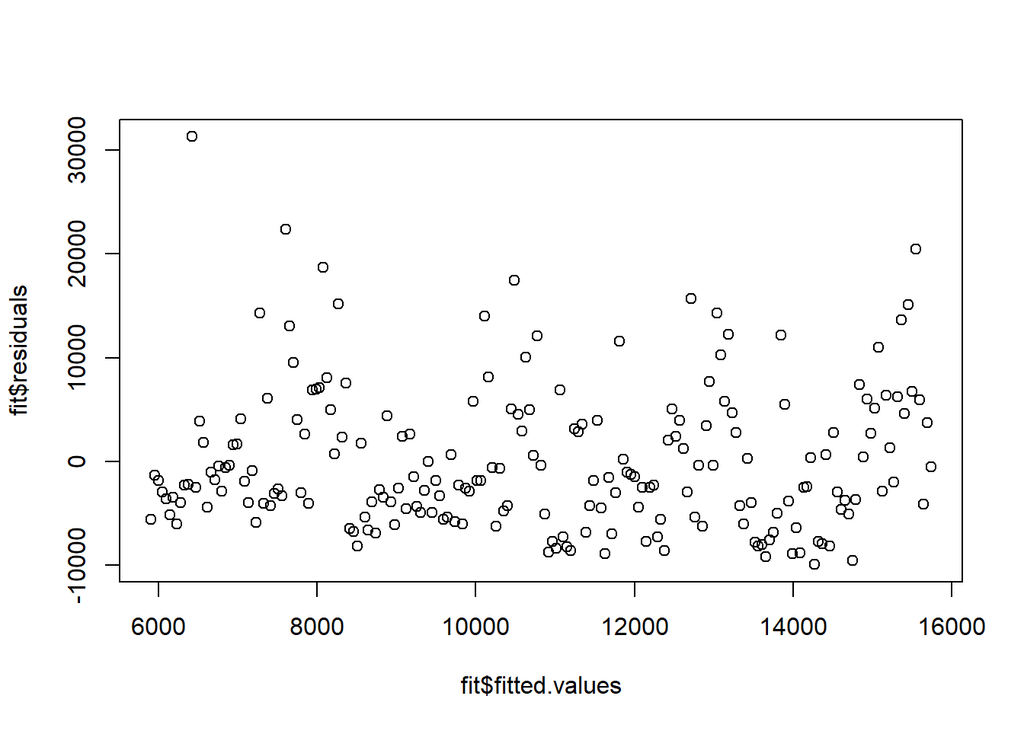

```r
fit = lm(sales_ts_weekly ~ time(sales_ts_weekly))
plot(fit$residuals ~ fit$fitted.values)
```

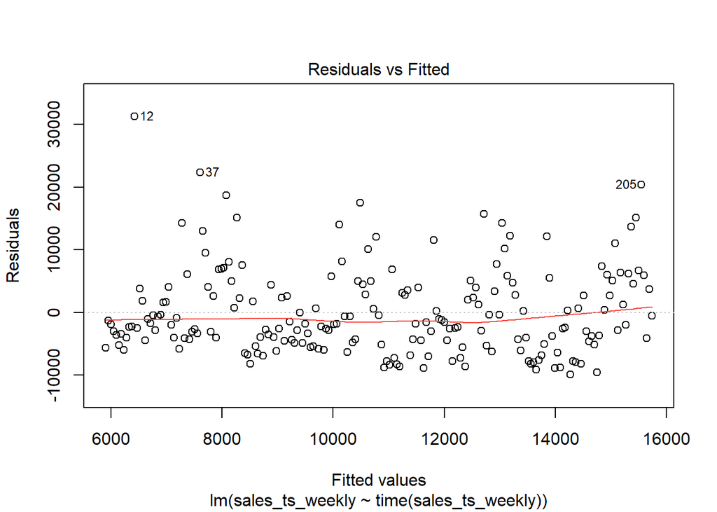

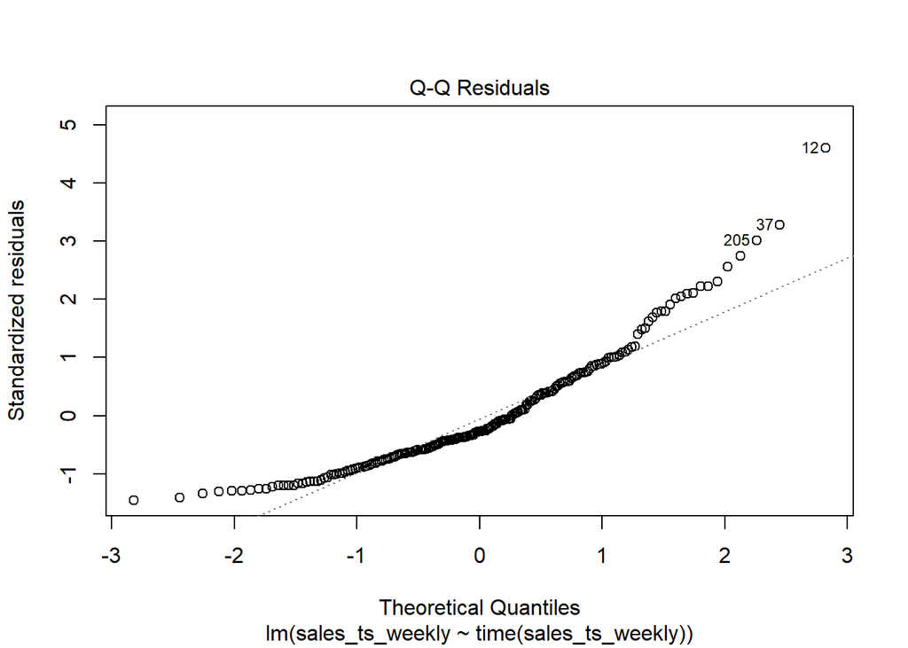

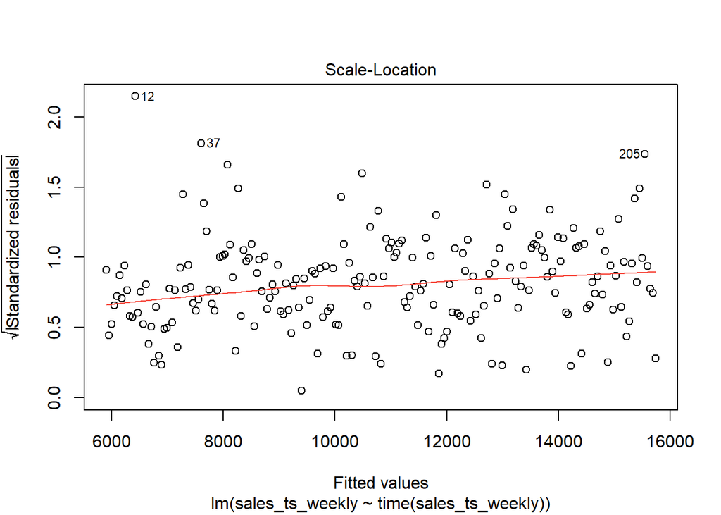

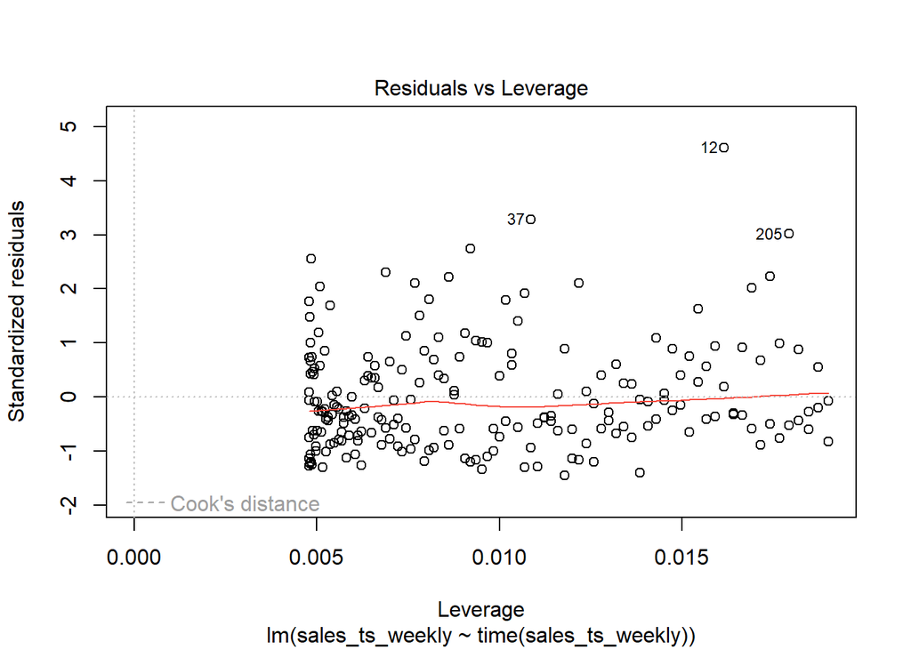

```r
plot(fit)
```

```r
boxcox(fit)
```

```r
model4 = Arima(sales_ts_weekly, order=c(0, 1, 1), seasonal=list(order=c(0, 1, 1), period=52), lambda="auto")
summary(model4)
```

```
## Series: sales_ts_weekly
## ARIMA(0,1,1)(0,1,1)[52]
## Box Cox transformation: lambda= 0.838912
##
## Coefficients:
##           ma1     sma1
##       -0.9785  -0.6870
## s.e.   0.0260   0.2187
##
## sigma^2 = 1908740:  log likelihood = -1365.41
## AIC=2736.82   AICc=2736.98   BIC=2745.97
##
## Training set error measures:
##                    ME     RMSE      MAE       MPE     MAPE      MASE
## Training set 275.8884 5485.836 3434.846 -20.33185 44.13758 0.6130987
##                     ACF1
## Training set -0.08095574
```

```r
coeftest(model4)
```

```
##
## z test of coefficients:
##
##       Estimate Std. Error  z value  Pr(>|z|)
## ma1  -0.978457   0.025975 -37.6699 < 2.2e-16 ***
## sma1 -0.686975   0.218743  -3.1406  0.001686 **
## ---
## Signif. codes:  0 '***' 0.001 '**' 0.01 '*' 0.05 '.' 0.1 ' ' 1
```

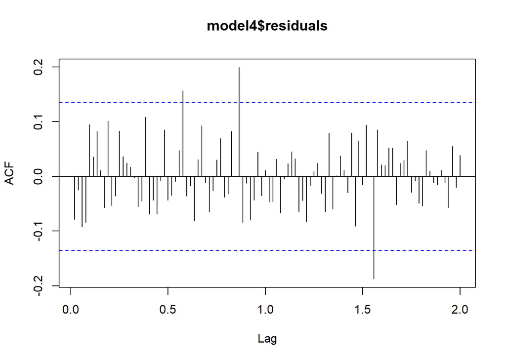

```r
Acf(model4$residuals, lag.max=104)
```

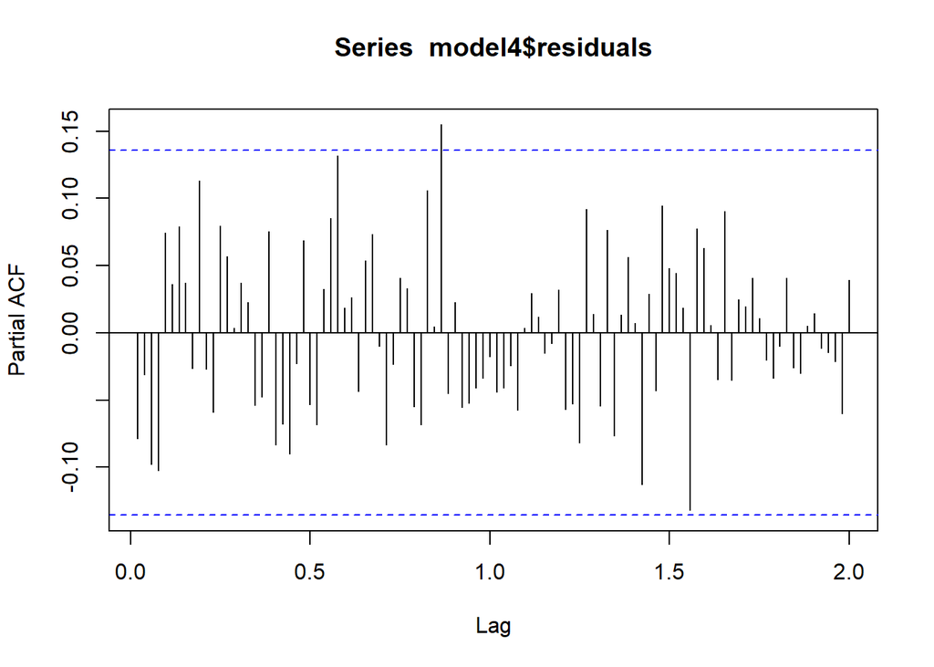

```r
pacf(model4$residuals, lag.max=104)
```

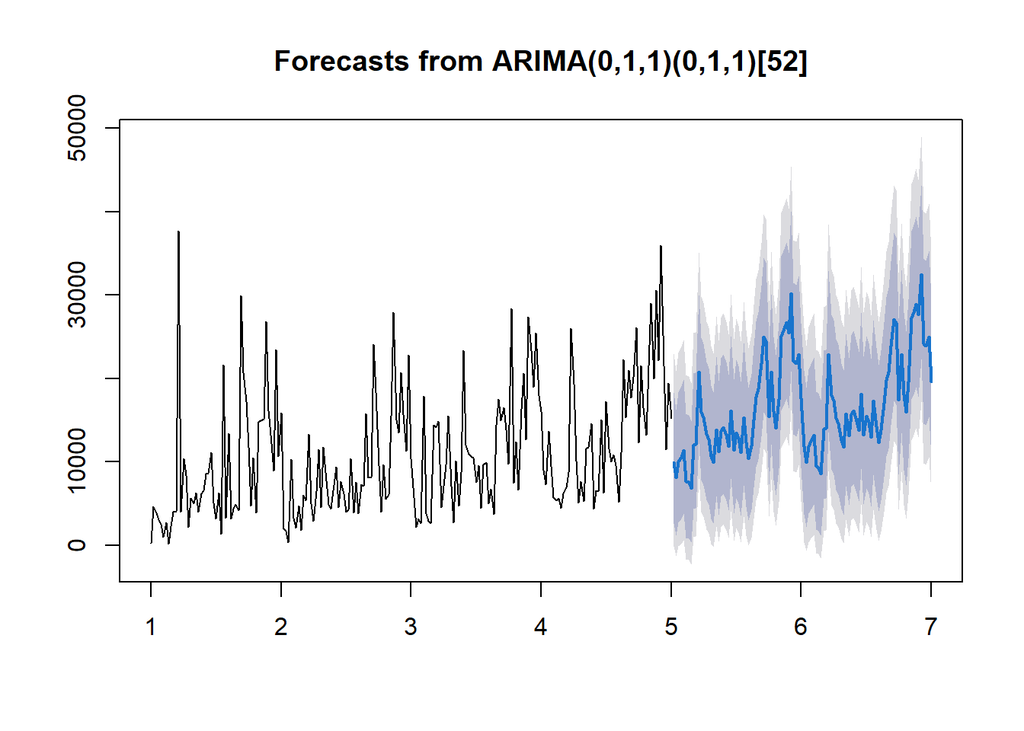

```r
plot(forecast(model4, h=104))
```

```r
residuals <- residuals(model4)
Box.test(residuals, lag = 10, type = "Ljung-Box")
```

```
##
##  Box-Ljung test
##
## data:  residuals
## X-squared = 11.49, df = 10, p-value = 0.3207
```